# ML output to occupancy simulations

```r
library(tidyverse)
library(fastDummies)
library(stringi)
library(lubridate)
library(ezknitr)
library(here)
```

```r
dat<-read_csv("Output/ceah_for_occ.csv")
```

This dataset (imported on the line above contains all Machine Learning (ML) output from the CEAH images from FL and CA from the period of February 2015 - August 2017, which is about 5 million images. The date, sequence number (aka burst #’s), and Event Number (aka unique # for each burst) have been extracted using the ExifTool application and merged to the ML output. The dates were then converted to POSIXct and specific date categories were compiled (hour, day, week, etc).

```r
refs<-read_csv("Output/ready_for_occ_analysis/camera_deploy_dates.csv")
```

This has the official camera deployment dates as well as the last datetime an image was taken for a camera. Assuming there wasn’t a complete absence of any detections (of any spp) at the end, this should be a fine way to get the end date.

```r
#Format date table
refs$end.date<-as.POSIXct(refs$end.date, format="%m/%d/%Y")
refs$SetDate<-as.POSIXct(refs$SetDate, format="%m/%d/%Y")
```

```r
source("Scripts/helper_functions_for_creating_occupancy_tables.R")
```

The preceding functions were made to help in the post-processing of ML output into occupancy tables ready for analysis.

The first function ‘occ_db’ takes a dataframe (such as what you’d have as output from the ML model) that contains variables for 1) camera ID, 2) species to create occupancy table for (only works for single species for now), and 3) a column for time interval of interest (e.g. a week column listing the week number for each observation) At this point, the only time intervals that are accepted are day, week, and month (hour can eventually be added)

The second function ‘add_zero_cols’ takes the inputs of the table with the deployments and end of the active period for all cameras and makes sure that there is a full sequence of time-interval columns and that they match up for all cameras. The beginning is the when the first camera was deployed, and the end is the last active date for any camera.

The third function ‘insert_NA’ takes the output of the second function and does several steps: 1) Makes a temporary dataframe which stores the start and end dates which each camera has data for, 2) Cycles through each cam and determines if the start dates for the camera are after the global start dates, (global start date==the first date for any camera which will determine the first time interval for the occupancy table) 3) If the camera starts later than the global start, then NA’s are inserted into the columns for which there isn’t data for that specific camera and a message is printed saying that NA’s are being inserted. 4) The same process is repeated for the end dates Btw, if the start and end dates are within one time interval from the global times, no NA’s are inserted and a message is printed that states as much.

### Simulations

The confidence values for which to filter values by will be considered in two ways: 1) by comparing the number of occupancy intervals affected when compared to a 0.5 confidence baseline, and 2) by comparing to a flat baseline where no filtering is applied

The resulting output will show the proportion of time intervals that switch from 1 to 0 as you cut out data.

```r
### Simulations for weekly time interval with pig as focal sp
confs<-seq(0.51, .99, 0.01)
week_res<-data.frame(thresholds=confs, occ_int_changed=NA, prop_changed=NA)

# 50% confidence to compare to
baseline50<-occ_db(df=dat,
                   species = 22,
                   thresh = 0.5,
                   time_int = 'week')

baseline50<-add_zero_cols(occ_df = baseline50,
                          cam_set_dates = refs$SetDate,
                          camID = refs$camID,
                          time_int = 'week',
                          dates_full_df = dat$DateTimeOriginal)

baseline50<-insert_NA(occ_dataframe = baseline50,
                      full_dataframe = dat,
                      time_int = 'week')
b50<-sum(rowSums(baseline50[,-1], na.rm = T))

# all the other confidence values between 50 and 99%
for(i in 1:nrow(week_res)){
  tmp<-occ_db(df=dat, species = 22, thresh = confs[i], time_int = 'week') #22 is wild pig species label
  tmp<-add_zero_cols(occ_df = tmp, cam_set_dates = refs$SetDate, camID = refs$camID, time_int = 'week',dates_full_df = dat$DateTimeOriginal)
  tmp<-insert_NA(occ_dataframe = tmp, full_dataframe = dat, time_int = 'week')
  week_res[i, 2]<-b50-sum(rowSums(tmp[,-1], na.rm = T))
  week_res[i, 3]<-week_res[i,2]/b50
  print(paste('Confidence value', confs[i], sep=' '))
}
```

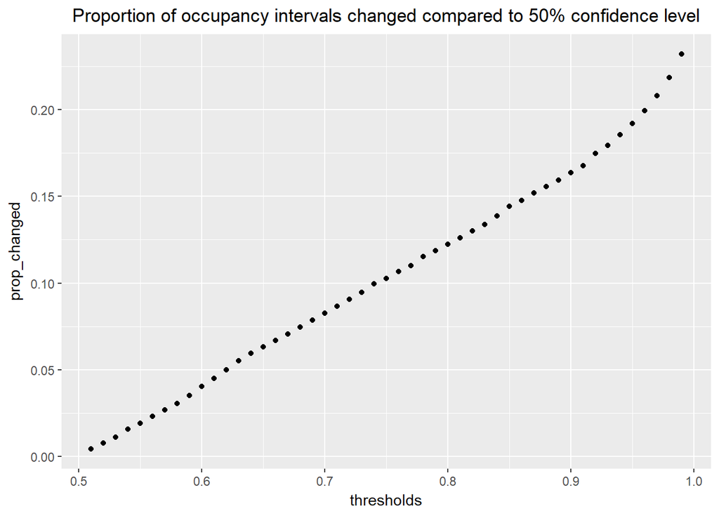

```r
ggplot(week_res, aes(thresholds, prop_changed))+geom_point()+
  ggtitle("Proportion of occupancy intervals changed compared to 50% confidence level")+
  theme(plot.title=element_text(hjust=0.5))
```

The following is if compared to a baseline of no confidence filter

```r
bzero<-occ_db(df=dat,
                   species = 22,
                   thresh = 0,
                   time_int = 'week')

bzero<-add_zero_cols(occ_df = bzero,
                          cam_set_dates = refs$SetDate,
                          camID = refs$camID,
                          time_int = 'week',
                          dates_full_df = dat$DateTimeOriginal)

bzero<-insert_NA(occ_dataframe = bzero,
                      full_dataframe = dat,
                      time_int = 'week')
b0<-sum(rowSums(bzero[,-1], na.rm=T))


#' all confidence values between 0.01 and 0.99
confs<-seq(0.01, .99, 0.01)
week_res<-data.frame(thresholds=confs, occ_int_changed=NA, prop_changed=NA)


for(i in 1:nrow(week_res)){
  tmp<-occ_db(df=dat, species = 22, thresh = confs[i], time_int = 'week') #22 is wild pig species label
  tmp<-add_zero_cols(occ_df = tmp, cam_set_dates = refs$SetDate, camID = refs$camID, time_int = 'week',dates_full_df = dat$DateTimeOriginal)
  tmp<-insert_NA(occ_dataframe = tmp, full_dataframe = dat, time_int = 'week')
  week_res[i, 2]<-b0-sum(rowSums(tmp[,-1], na.rm = T))
  week_res[i, 3]<-week_res[i,2]/b0
  print(paste('Confidence value', confs[i], sep=' '))
}
```

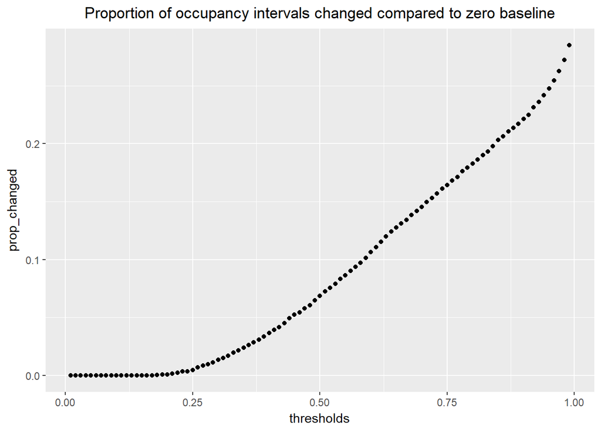

```r
ggplot(week_res, aes(thresholds, prop_changed))+geom_point()+
  ggtitle("Proportion of occupancy intervals changed compared to zero baseline")+
  theme(plot.title=element_text(hjust=0.5))
```